Home > Supervised Learning > Bayes and Naive Bayes Classification > Bayes Classification

# 2.2.3.1 Bayes Classification

In an ideal world, we have for each class $c = 1,...,C$ the probability for $x$ to belong to the $c$-th class. For example if we are classifying fruits, $K_1$ could be “Banana”, $K_2$ could be “Apple” etc When we write $\mathbb{P}(K_c |x)$ we are asking: “Given that we observed $x$, what is the probability that it belongs to class $c$?” If we denote the event of belonging to class $c$ by $K_c$, we know the conditional probabilities $\mathbb{P}(x |K_c)$ (in English: *conditional distributions*), e.g. $\mathbb{P}(1003g, \text{red|Banana}) = 0\%$. Thus, we can use Bayes’ theorem to obtain
$$\mathbb{P}(K_c|x) =
\frac{\mathbb{P}(K_c)\mathbb{P}(x|K_c)}{\mathbb{P}(x)} =
\frac{\mathbb{P}(K_c)\mathbb{P}(x|K_c)}{\sum_{i=1}^C
\mathbb{P}(K_i)\mathbb{P}(x|K_i)}$$

#### Explanation

- $\mathbb{P}(K_c)$ is the **prior probability** of class $c$, i.e. how common this class is in general. It is denoted as $\pi_c$
- $\mathbb{P}(x |K_c)$ is the **likelihood**, meaning the probability of observing $x$ given that it belongs to class $c$
- $\mathbb{P}(x)$ is the **total probability** of $x$ over all possible classes, which is computed as $\sum_{i=1}^C \mathbb{P}(K_i)\mathbb{P}(x|K_i)$

The probability $\mathbb{P}(K_c)$ of the $c$-th class is usually abbreviated as $\pi_c$ (in English: *class prior*), leading to

#### 2.2.9

$$\mathbb{P}(K_c|x) =
\frac{\pi_c\mathbb{P}(x|K_c)}{\sum_{i=1}^C
\pi_c\mathbb{P}(x|K_i)}$$
Classification is then done by choosing the most probable class, i.e.
$$\DeclareMathOperator*{\argmax}{arg\,max}
\argmax_{c=1}^C \frac{\pi_c\mathbb{P}(x|K_c)}{\sum_{i=1}^C
\pi_c\mathbb{P}(x|K_i)} = \argmax_{c=1}^C \hspace{0.1cm}
\pi_c\mathbb{P}(x |K_c)$$
(Since the denominator is the same for all classes, we can just compute the numerator!) This means:

- Compute $\pi_c \mathbb{P}(x|K_c)$ for each class
- Pick the class with the highest value!

#### Example: Classifying fruits

Imagine we want to classify a fruit $x$ based on **weight** and **color**. Suppose we have

- Bananas $(K_1)$: 90% of bananas are yellow and 10% are green
- Apples ($K_2)$: 50% are red, 40% are green and 10% are yellow
- Cherries $(K_3)$: 95% are red, 5% are yellow

If we observe $x = (1003g, red)$, the probability of observing that for each fruit is

- $\mathbb{P}(x | K_1)$ (prob of a 1003g red banana) is 0% –> bananas are never red
- $\mathbb{P}(x|K_2)$ is 50%
- $\mathbb{P}(x|K_3)$ is 95% If apples and cherries are equally common, we classify $x$ as a **cherry** since it has the highest probability

#### Back to the script

The mapping $x \mapsto \argmax_{c=1}^C \pi_c \mathbb{P}(x|K_c)$ is also called the Bayes classifier. This means that given some feature $x$, we assign it to the class $K_c$ that maximizes $\pi_c \mathbb{P}(x|K_c)$ Note that this is independent of the denominator in #2.2.9 Often, $x$ is a continuous random variable, making it meaningless to work with $\mathbb{P}(x |K_c)$: If $x|K_c$ is, for example, normally distributed, then $\mathbb{P}(x |K_c) = 0$ for all $x \in \mathbb{R}^d$ In this case, however we can use Bayes’ theorem for densities and obtain

#### 2.2.10

$$\mathbb{P}(K_c|x) = \frac{\pi_c
p(x|K_c)}{\sum_{i=1}^C \pi_cp(x|K_i)}$$
where $p(x|K_c)$ are the conditional **densities** ($p(x|K_c)$ now is a PDF of $x$ given class $K_c$). Note that the left side still represents a probability and not a density since the possible classes form a discrete and finite probability space! In practe, we unfortunately have neither $\pi_i$ nor $\mathbb{P}(x |K_c)$ or $p(x|K_c)$ available. Both quantities must be approximated using the data. To this end, one can use the class proportions:
$$\hat{\pi}_c := \frac{\#\{i =
1,...,N \hspace{0.1cm} | \hspace{0.1cm} y_i = l_c\}}{N}$$
This just means:

- $l_c$ represents the label for the class
- $y_i = l_c$ means “the $i$-th sample is in class $c$”
- Count how many times class $c$ appears in the training data
- Divide by the total number of samples $N$ … and is used regardless of discrete or continuous case (see below!)

Additionally, the conditional probabilities $\mathbb{P}(x|K_c)$ or densities $p(x|K_c)$ must be suitably approximated by $\hat{P}(x|K_c)$ or $\hat{p}(x|K_c)$. - $\hat{P}(x|K_c)$ is an approximation of the probability $\mathbb{P}(x|K_c)$ when $x$ is discrete (e.g. categorical features) - $\hat{p}(x|K_c)$ is an approximation of the probability density function $p(x|K_c)$ when $x$ is continuous (e.g. real-valued features)

We then obtain the approximate Bayes classifier:
$$x \mapsto \argmax_{c=1}^C
\hspace{0.1cm}\hat{\pi}\hat{P}(x|K_c) \hspace{0.5cm} \text{or}
\hspace{0.5cm} x \mapsto \argmax_{c=1}^C\hspace{0.1cm} \hat{\pi}_c
\hat{p}(x|K_c)$$
This means:

1. Compute the estimated prior $\pi_c$+
2. Compute the estimated probability (depending on the case discrete or continuous)
3. Assign $x$ to the class $c$ that maximizes

#### Discrete Random Variables

If $x |K_c$ is a discrete random variable (e.g. colors red, green, yellow), one can approximate $\mathbb{P}(x|K_c)$ by proportions in the training data, e.g.

$$\hat{P}(\text{red}|K_c) := \frac{\#\{i
|x_i = \text{red}, y_i = l_c\}}{\# \{i | y_i = l_c\}}$$
This means:

- **Numerator**: number of samples where $x_i$ (the feature) is red **and** the label $y_i$ is class $c$
- **Denominator**: total number of samples in class $c$

#### Example

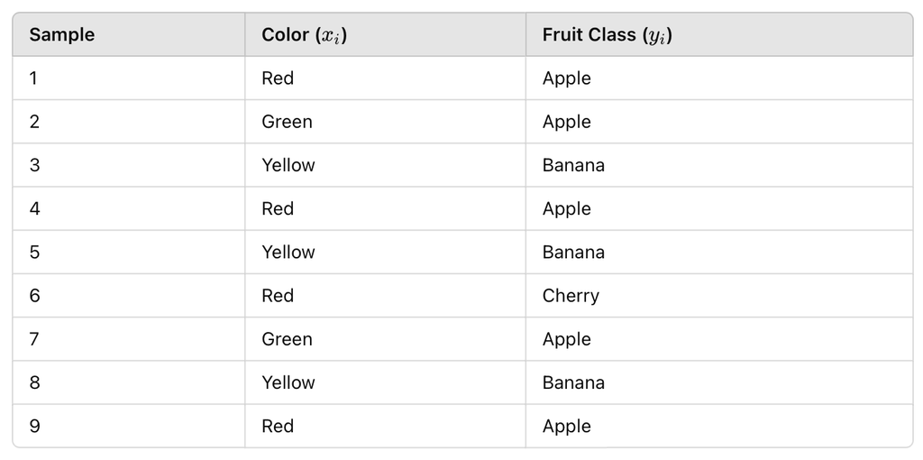

#### Gaussian Mixture Model

For continuous variables, a common assumption is that $x|K_c \sim \mathcal{N}(\mu_c, \sigma_c^2)$ is normally distributed with means $\mu_c$ and variances $\sigma_c^2$ for $c=1,...,C$. For simplicity, we will only consider the one-dimensional case here. We can approximate the densities $p(x|K_c)$ for $x \in \mathbb{R}$ by
$$\hat{p}(x|K_c) := \frac{1}{\sqrt{2\pi
\hat{\sigma_c}^2}}
\text{exp}\biggl(-\frac{(x-\hat{\mu}_c)^2}{2\hat{\sigma_c}^2}\biggl)$$
for $c = 1,...,C$ where
$$\mu_c = \frac{1}{\#\{i | y_i = l_c\}}\sum_{i |y_i
= l_c}x_i
\hspace{1cm}
\hat{\sigma}_c^2 := \frac{1}{\#\{i | y_i = l_c\}}
\sum_{i|y_i=l_c}(x_i-\mu_c)^2$$
are the mean and discrete variance of the points with label $l_c$ - $\mu_c$ is just the average of all feature values $x_i$ that belong to class $c$ - The denominator is the number of training samples in class $c$ - The numerator sums all $x_i$ values for class $c$ - $\hat{\sigma_c}^2$ is the variance estimate, which calculates the **spread** of values around the meaen - Each sample’s difference from the mean is squared and summed, then divided by the number of samples of training points in class $c$

#### Kernel Density Classification

If the distribution of $x |K_c$ is more complicated, the Gaussian Mixture Model may not be a good choice. In this case, one can approximate it using a so-called kernel density estimator. We also restrict ourselves here to the case $d=1$, i.e. the inputs are **one-dimensional**. We define

#### 2.2.12

$$\hat{p}(x|K_c) := \frac{1}{\#\{i|y_i =
l_c\}} \sum_{i|y_i=l_c} K_\lambda (x-x_i)$$
where $\lambda >0$ is the bandwidth, $K_\lambda(x) := \frac{1}{\lambda}K(\frac{x}{\lambda})$ and $K : \mathbb{R} \to \mathbb{R}$ is a non-negative function with $\int_\mathbb{R} K(x)dx = 1$. Possible choices are the **Gaussian kernel**
$$K(x) :=
(2\pi)^{-1/2}\text{exp}(-x^2/2)$$
or $K(x) := \frac{1}{2}1_{|x| \leq 1}$. However note that for the second choice, it may happen that $\hat{p}(x|K_c) = 0$ for all $c= 1,...,C$ which does not allow for class assignment. This approach depends on the choice of bandwidth $\lambda$. In particular, for $0 \lt \lambda \ll 1$, $\hat{p}(x|K_c) \approx 0$ if $x$ is not a training data point $x_i$. On the other hand, if $\lambda$ is very large, $\hat{p}(\cdot |K_c)$ is nearly constant. It can be shown that an optimal choice of $\lambda$ for large values of $n \in \mathbb{N}$ takes the form $\lambda = Cn^{-\frac{1}{5}}$. For normally distributed data $x_i \sim \mathcal{N}(\mu, \sigma^2)$, the optimal constant is given by $C = (\frac{4}{3})^{\frac{1}{5}}\sigma$

Next up: 2.2.3.2 Naive Bayes Classification